# ECo 602 - Analysis of Environmental Data

Final Project

Ayodele O’uhuru

Fall 2020

# Introduction

This reference guide was created for my Analysis of Environmental Data final, but I know I will use this for years to come as a to help retain the skills learned from this class, The first couple sections dive into the functions used this semester. The second part uses the information from the Delomys data set.

# Functions 1: Data Structure Functions

Look at the source code for the final project template, you’ll notice the text:

`{.tabset .tabset-pills}`

This creates tabbed content for all the following sections that are one-level below.

- If you include them on a primary header (one #), all of the subsequent secondary headers will in tabs.
  - This is really good when trying to make an oraganized page with code.

## `c()`

The function `c()` *combines* or *concatenates* its arguments into a vector (a 1-dimensional data structure consisting of 1 or more elements).

- All of the elements must be of the same *type*.
  - I can’t combine character and numeric types in the same call to `c()`

Here’s two examples using numeric and character data types:

```r
# Create a vector of numbers:
num_vec  = c(1, 4, 8, 9, 13)

# Create a vector of characters:
char_vec = c("a", "fish", "data is cool")
```

I can show the contents of a vector by typing the name of the vector, or using the `print()` function.

```r
# Typing the name of the vector into the console prints the contents
num_vec
```

```
## [1]  1  4  8  9 13
```

```r
# The print() function accomplishes the same task:
print(char_vec)
```

```
## [1] "a"            "fish"         "data is cool"
```

## `data.frame()`

How to subset a data frame:

- If I know the name of the column, I can use the $ symbol

`data.frame()`

```r
  #Build a data from scratch:
dat_1 = data.frame(
  letters = c("A", "y", "a"),
  numbers_1 = c(13, 4, 123454))

# I can print the contents by typing the name of the data frame
dat_1
```

```
##   letters numbers_1
## 1       A        13
## 2       y         4
## 3       a    123454
```

```r
#subset a column by name
dat_1$letters
```

```
## [1] "A" "y" "a"
```

## `matrix()`

A matrix is a group of elements of the same type, arranged by rows and columns. Matrices are always two-dimensional

-`byrow` tells the matrix to fill by row; if you set `byrow=FALSE` it will set matrix to fill by column.

- This is also a good time to mention when writing `FALSE` or `TRUE` it can also be shortened to `F` or `T`
- The components to create a matrix will be:
  - (rows:columns, arrange by row or column, how many rows/ columns it should be)

```r
#Basic Matrix (shorthand):
matrix(2:10, byrow = T, nrow = 3)
```

```
##      [,1] [,2] [,3]
## [1,]    2    3    4
## [2,]    5    6    7
## [3,]    8    9   10
```

```r
matrix(c(1,2,3,4,5,6,7,8,9), byrow = T, nrow = 3) # Longhand
```

```
##      [,1] [,2] [,3]
## [1,]    1    2    3
## [2,]    4    5    6
## [3,]    7    8    9
```

## `length()`

`length()` function can be used to get or set the length of a vector or factor. Lets recall the previous example for a vector:

```r
# Create a vector of numbers:
num_vec  = c(1, 4, 8, 9, 13)

# Create a vector of characters:
char_vec = c("a", "fish", "data is cool")
```

Now lets find the length of the two vectors above:

```r
# you can see here that the length of the `num_vec` is 5
length(num_vec)
```

```
## [1] 5
```

```r
# The length of `char_vec` is 3
length(char_vec)
```

```
## [1] 3
```

## `nrow()`

`nrow` tells matrix how many rows to have. The `nrow` function can be used within a matrix that is distributed by its rows.

```r
  # Building a Matrix by row:
  matrix(10:34, byrow = T, nrow = 5)
```

```
##      [,1] [,2] [,3] [,4] [,5]
## [1,]   10   11   12   13   14
## [2,]   15   16   17   18   19
## [3,]   20   21   22   23   24
## [4,]   25   26   27   28   29
## [5,]   30   31   32   33   34
```

## `ncol()`

-`ncol` function tells the matrix how many columns to have when you set the `byrow = FALSE`.

- This is also a good time to reiterate when writing `FALSE` or `TRUE` it can also be shortened to `F` or `T`

```r
# Building a Matrix by column:
  matrix(1:15, byrow = FALSE, ncol = 5)
```

```
##      [,1] [,2] [,3] [,4] [,5]
## [1,]    1    4    7   10   13
## [2,]    2    5    8   11   14
## [3,]    3    6    9   12   15
```

## `dim()`

Just like `Length()`, `dim()` function finds the dimension of an object.

Lets recall the example of the matrix:

```r
  # Building a Matrix by row:
  mat_row= matrix(10:34, byrow = T, nrow = 5)

 #Using the dim() function:
dim(mat_row)
```

```
## [1] 5 5
```

```r
#the output tells us that there are 5 rows, and 5 columns
```

# Functions 2: Numerical Data Exploration

## `summary()`

`summary()` is a function that tells you the summary of the given object.

```r
# Load penguins package:
require(palmerpenguins)

#We want to look at the summary for the species column of the penguins data frame:
summary(penguins$species)
```

```
##    Adelie Chinstrap    Gentoo
##       152        68       124
```

```r
#This tells us the different species, and how many observations of each there are.
```

## `mean()`

The `mean()` is a arithmetic function. We can use r to do basic computations.

```r
scores= c(1,486,3968,743,4,2)
mean(scores)
```

```
## [1] 867.3333
```

## `sd()`

The `sd()` function outputs the standard deviation. This function uses the argument `na.rm` which will allow you to keep or remove missing values. `sd()`

```r
sd(penguins$bill_length_mm, na.rm = TRUE)
```

```
## [1] 5.459584
```

```r
# When na.rm is TRUE: It removes missing values
sd(penguins$bill_length_mm, na.rm = FALSE)
```

```
## [1] NA
```

```r
#when na.rm is FALSE: it does not remove missing values, which does not print out a numeric number
```

# Functions 3: Graphical Data Exploration

## `subset()`

For this function, we want to pull out the species subset of the full data set `palmerpenguins`.

- The use of the double = or `==` is a binary operation that tests for equality. in this example it pulls out one specific species in the subset species.
- The binary operation `!=` means it is not equal to.

```r
#Lets require data set:
require(palmerpenguins)
penguin_dat = droplevels(subset(penguins, species != "Gentoo"))
dat_adelie = subset(penguin_dat, species == "Adelie")
dat_chinstrap = subset(penguin_dat, species == "Chinstrap")
```

## `par()` and `mfrow=`

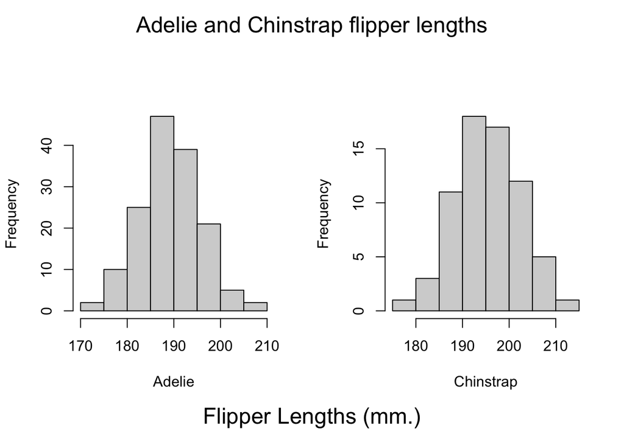

```r
par(mfrow = c(1, 2), oma=c(2,0,2,0))
hist(dat_adelie$flipper_length_mm, xlab = "Adelie", main = "")
hist(dat_chinstrap$flipper_length_mm, xlab = "Chinstrap", main= "")
mtext("Adelie and Chinstrap flipper lengths", side = 3, outer = T, line = 0, cex = 1.5)
mtext("Flipper Lengths (mm.)", side = 1, outer = T, line = 0, cex = 1.5)
```

## `plot()`

I can use `plot()` to create scatterplots

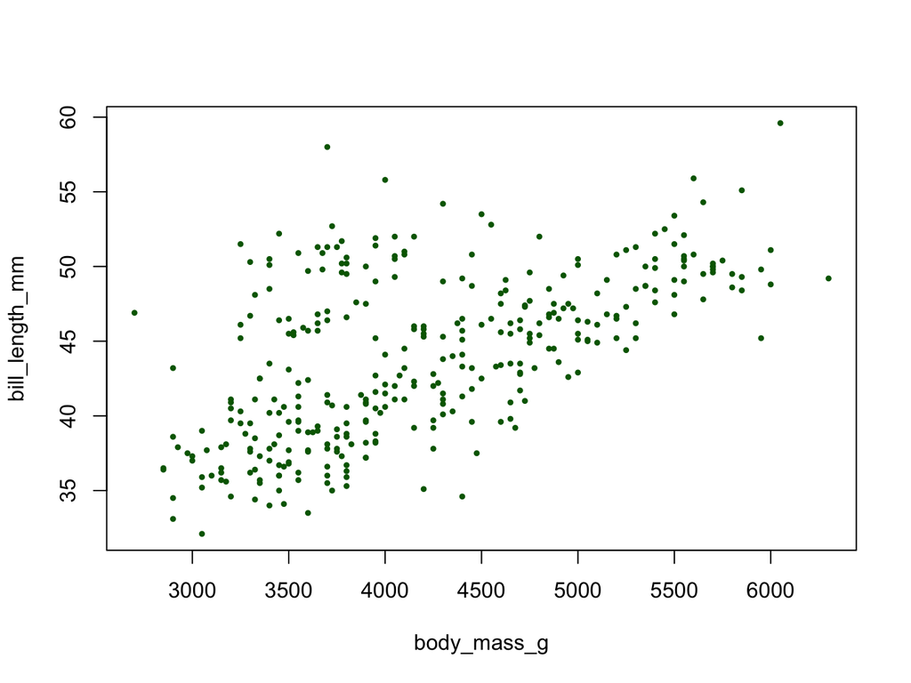

```r
# load the penguins package:
require(palmerpenguins)

#using formula notation:
# I can use the pch argument to change the symbol
#`col=`  can be used to change the color of the symbol.
# `cex=` will change the size of the symbol, you can play around with this number to best fit the plot.
plot(bill_length_mm ~ body_mass_g,
     data = penguins,
     pch= 20, col= "dark green",
     cex= .7)
```

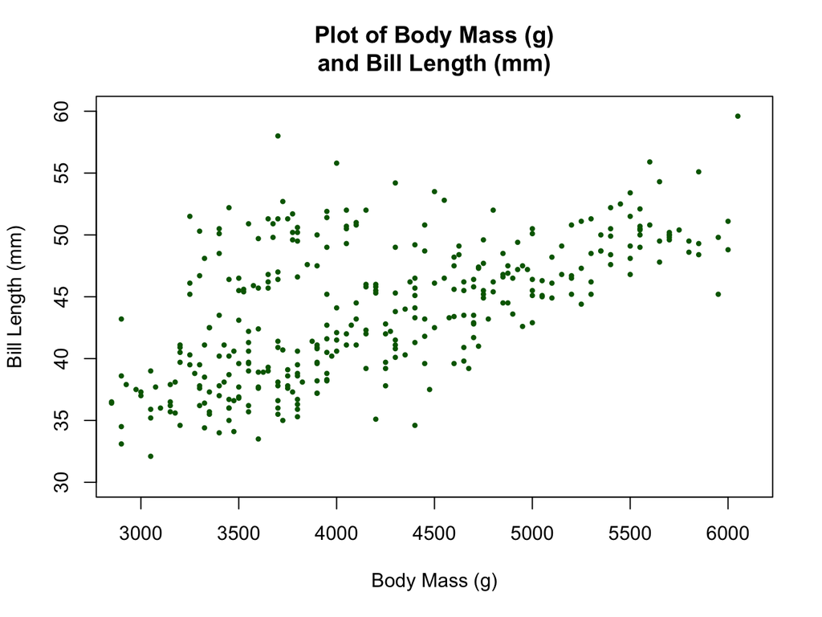

```r
#Next lets look into the parameters for the plot itself
plot(bill_length_mm ~ body_mass_g,
     data = penguins,
     pch= 20, col= "dark green",
     cex= .7,
     main = "Plot of Body Mass (g)\nand Bill Length (mm)",
     ylab= "Bill Length (mm)",
     xlab= "Body Mass (g)",
     xlim= c(2900,6100),ylim=c(30,60))
```

## `boxplot()`

A boxplot is the same as a box and whisker plot. It shows a visual summary of the minimum, Q1, median, Q2, and the maximum points of a data range. The Q1, median, and Q3 represents the IQR that shows the range of 50% of the information from 25-75th percentile. dev.off()

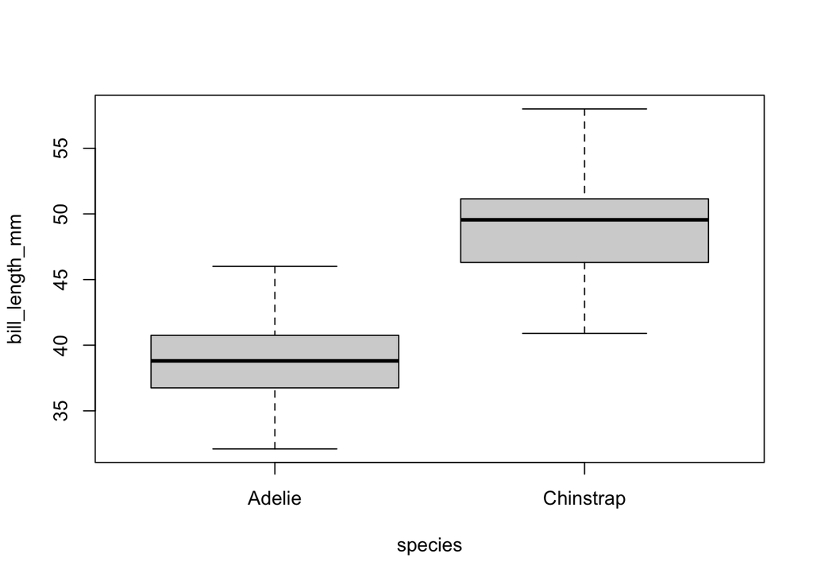

```r
#This is just a boxplot between the bill length and the species
boxplot(bill_length_mm ~ species,
     data = penguin_dat)
```

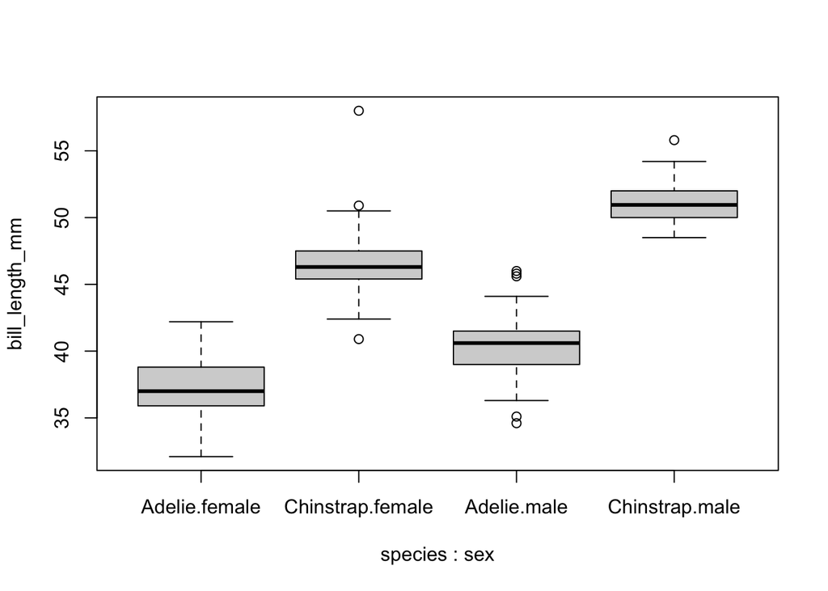

```r
#This boxplot of bill length that is conditioned by both species and the sex
boxplot(bill_length_mm ~ species * sex,
     data = penguin_dat)
```

## `hist()`

#The breaks argument will suggest to R to create a certain number of bins

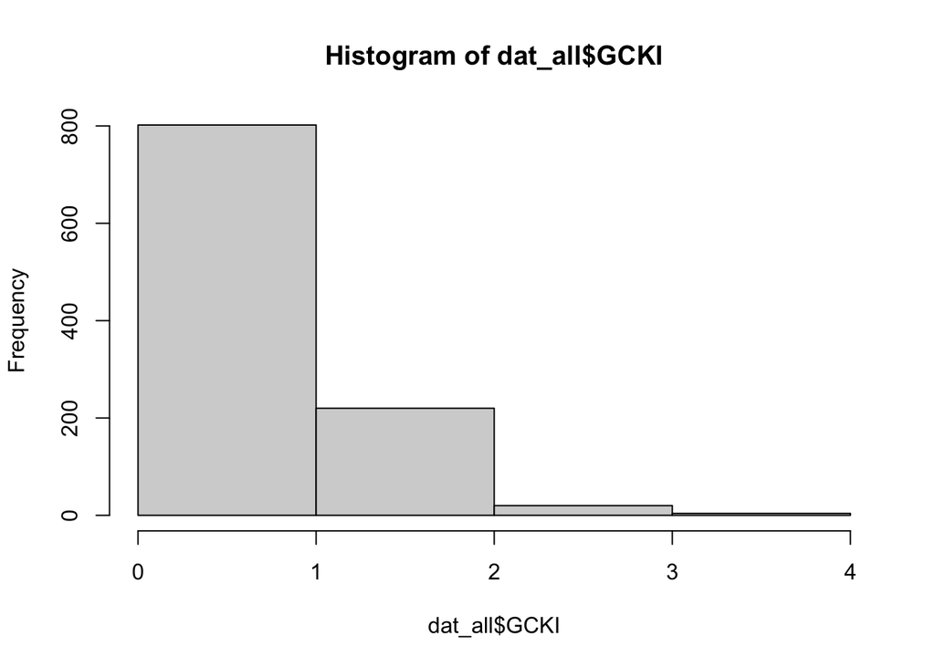

```r
#First Load bird data:
dat_bird = read.csv("https://michaelfrancenelson.github.io/eco_602_634_2020/data/bird.sta.csv", TRUE)
dat_habitat = read.csv("https://michaelfrancenelson.github.io/eco_602_634_2020/data/hab.sta.csv", TRUE)
dat_all = merge(dat_bird, dat_habitat)

#Lets now create a histogram with 4 bins for GCKI:
hist(dat_all$GCKI, breaks = 4)
```

# Functions 4: Distribution Functions

Distribution functions are very useful for both discrete and continuous distributions. `dnorm()`, `pnorm()`, and `qnorm()` are all functions used for continuous normal distribution. `dbinom()`, `pbinom()`, and `qbinom()` are functions for binomal discrete distribution.

## `dnorm()`

The d - in `dnorm()` stands for density. The function will tell the probability density of the set. The arguments are x (or independent variable), mean, and sd (or standard deviation).

`dnorm()`

```r
dnorm(5, mean = 5, sd = 2)
```

```
## [1] 0.1994711
```

## `pnorm()`

The p - in `pnorm()` stands for probability. This function will show the cumulative density.

`pnorm(q, mean = 0, sd = 1, lower.tail = TRUE, log.p = FALSE)`

`pnorm()`

```r
pnorm(8, mean = 12, sd = 4)
```

```
## [1] 0.1586553
```

## `qnorm()`

The q - in `qnorm()` stands for quanitle. This will tell what the quantile is of the set of numbers. The function computes the inverse of the `pnorm` function.

`qnorm(p, mean = 0, sd = 1, lower.tail = TRUE, log.p = FALSE)`

`qnorm()`

```r
qnorm(.8, mean = 12, sd = 4)
```

```
## [1] 15.36648
```

## `dbinom()`

The `dbinom()` function tells the probability mass function. This function can help find the probability when a values is exaclty x.

```r
dbinom(12, 15, 0.2)
```

```
## [1] 9.542042e-07
```

```r
dbinom(12, 15, 0.8)
```

```
## [1] 0.2501389
```

## `pbinom()`

The `pbinom()` function tells the cumulative mass. This function can help find the probability when an observed value is less or more than x.

```r
pbinom(10, 20, 0.2)
```

```
## [1] 0.9994366
```

```r
pbinom(10, 20, 0.4)
```

```
## [1] 0.8724788
```

## `qbinom()`

The `qbinom() is the quantile function. The function can help when you arw looking for the median or a particular percentile.

```r
qbinom(.40, 200, .95)
```

```
## [1] 189
```

```r
qbinom(.40, 200, .5)
```

```
## [1] 98
```

# Functions 5: Other Functions

## `subset()`

For this function, we want to pull out the species subset of the full data set `palmerpenguins`. -The use of the double = or `==` is a binary operation that tests for equality. in this example it pulls out one specific species in the subset species.

- The binary operation `!=` means it is not equal to.

```r
#Lets require data set:
require(palmerpenguins)
penguin_dat = droplevels(subset(penguins, species != "Gentoo"))
dat_adelie = subset(penguin_dat, species == "Adelie")
dat_chinstrap = subset(penguin_dat, species == "Chinstrap")
```

## `library()` and `require()`

`library()` is a function that prints out all of the available saved packages in R. This is useful because it gives the name and its purpose all in one document. When you run the function without information inside of it, it will open up a new page with these different packages.

`require` is used to pull in one of these pre-loaded packages. When you use one of the packages listed in the library it will pull in the information without you having to physically install and tun the package.

```r
library()
require(palmerpenguins)
summary(penguins)
```

```
##       species          island    bill_length_mm  bill_depth_mm
##  Adelie   :152   Biscoe   :168   Min.   :32.10   Min.   :13.10
##  Chinstrap: 68   Dream    :124   1st Qu.:39.23   1st Qu.:15.60
##  Gentoo   :124   Torgersen: 52   Median :44.45   Median :17.30
##                                  Mean   :43.92   Mean   :17.15
##                                  3rd Qu.:48.50   3rd Qu.:18.70
##                                  Max.   :59.60   Max.   :21.50
##                                  NA's   :2       NA's   :2
##  flipper_length_mm  body_mass_g       sex           year
##  Min.   :172.0     Min.   :2700   female:165   Min.   :2007
##  1st Qu.:190.0     1st Qu.:3550   male  :168   1st Qu.:2007
##  Median :197.0     Median :4050   NA's  : 11   Median :2008
##  Mean   :200.9     Mean   :4202                Mean   :2008
##  3rd Qu.:213.0     3rd Qu.:4750                3rd Qu.:2009
##  Max.   :231.0     Max.   :6300                Max.   :2009
##  NA's   :2         NA's   :2
```

## `read.csv()`

The `read.csv()` function is used to read a file obtained from an outside source. you could set this function to a variable to create a data frame. It requires quotation marks because it is a string.

```r
# read.csv("https://michaelfrancenelson.github.io/eco_602_634_2020/data/bird.sta.csv")

# You can then set this function to a variable to create a data.frame

Bird_sta_data = read.csv("https://michaelfrancenelson.github.io/eco_602_634_2020/data/bird.sta.csv")
```

# Part 2: Data Anaylsis

## Loading Data

First we will load the data set using the `read.csv()` function:

```r
  #Load Delomys data:
  delomys= read.csv("https://michaelfrancenelson.github.io/eco_602_634_2020/data/delomys.csv")
```

## Numerical Exploration

`summary()`:

```r
#summary():
  summary(delomys$body_length)
  summary(delomys$body_mass)
```

```
##    Min. 1st Qu.  Median    Mean 3rd Qu.    Max.
##    49.0   106.0   116.0   114.7   124.0   265.0
##    Min. 1st Qu.  Median    Mean 3rd Qu.    Max.
##    5.00   35.00   43.00   44.06   54.00  105.00
```

`shapiro.test()`

```r
#Lets perform a test of normality on the body mass and length columns:
shapiro.test(delomys$body_mass)
shapiro.test(delomys$body_length)
```

```
##
##  Shapiro-Wilk normality test
##
## data:  delomys$body_mass
## W = 0.99506, p-value = 4.33e-05
##
##
##  Shapiro-Wilk normality test
##
## data:  delomys$body_length
## W = 0.87609, p-value < 2.2e-16
```

## Graphical Exploration

### Scatterplot

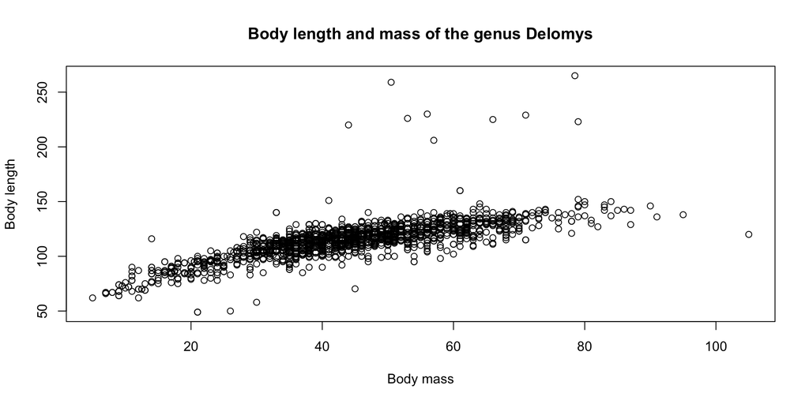

```r
#Scatterplot of body mass and body length:
plot(body_length ~ body_mass, data = delomys,
     main = "Body length and mass of the genus Delomys",
     xlab= "Body mass", ylab = "Body length")
```

### Historgram

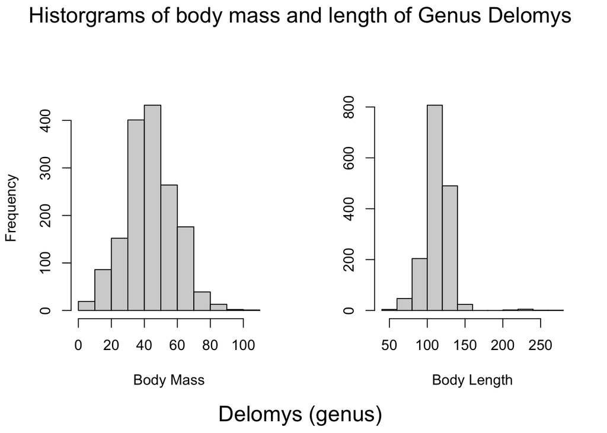

```r
par(mfrow = c(1, 2), oma=c(1.5,0,1.5,0))
# Histogram of body mass
hist(delomys$body_mass,
     main = "", xlab = "Body Mass")
# Histogram of body Length
hist(delomys$body_length,
    main= "", ylab = "", xlab = "Body Length") #Histogram of body Length
mtext("Historgrams of body mass and length of Genus Delomys ", side = 3, outer = T, line = 0, cex = 1.5)
mtext("Delomys (genus) ", side = 1, outer = T, line = 0, cex = 1.5)
```

### Boxplots

#### Boxplots of body mass by sex and by species

[figure not shown]

```r
par(mfrow= c(1,2), oma=c(0,0,1.5,0)) # This line sets the margins in order to add text.

# Conditional boxplot of body mass, conditioned on species:
boxplot(body_mass ~ binomial, data= delomys, xlab = "species",
        ylab = "Body mass",
        names = c("D.dorsalis", "D.sublineatus"))

# Conditional boxplot of body mass, conditioned on sex:
boxplot(body_mass ~ sex, data = delomys, ylab = "")
mtext("Boxplot of Delomy body mass by length and by species ",
      side = 3, outer = T, line = 0, cex = 1.5)
```

#### Boxplot of body mass conditioned on both species and sex

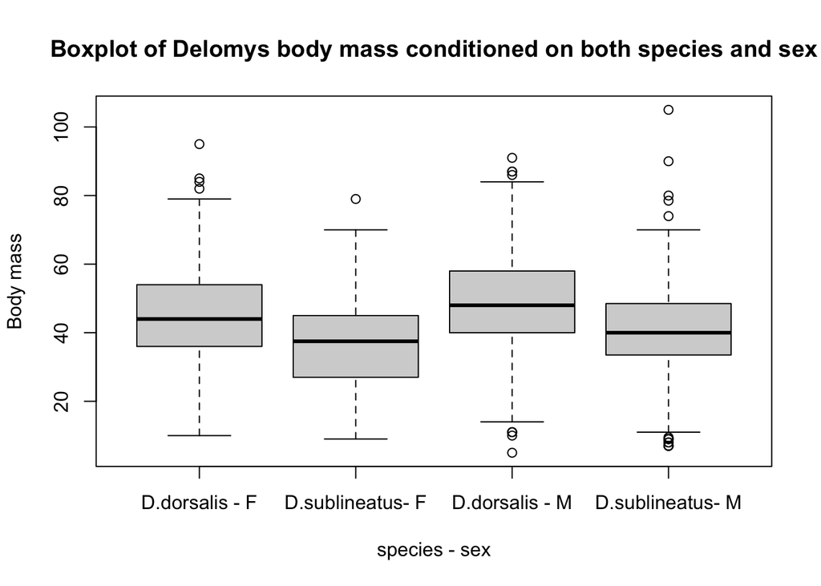

```r
# Conditional boxplot of body mass, conditioned on both species and sex
boxplot(body_mass ~ binomial * sex, data = delomys,
        names = c("D.dorsalis - F", "D.sublineatus- F", "D.dorsalis - M", "D.sublineatus- M"),
        main= "Boxplot of Delomys body mass conditioned on both species and sex",
        xlab= "species - sex", ylab = "Body mass")
```

## Model Building

We know that normality assumptions applies to the residual values after we fit a model.

For this section we will fit 5 models using the `lm()` function.

### Model 1 - Simple

```r
# Simple linear regression
fit_1 = lm(body_length ~ body_mass, data = delomys)
coef(fit_1)
```

```
## (Intercept)   body_mass
##  76.1246565   0.8754988
```

### Model 2 - Body Mass ~ Sex

```r
#1-way ANOVA
fit_2 = lm(body_mass ~ sex, data = delomys)
summary(fit_2)
```

```
##
## Call:
## lm(formula = body_mass ~ sex, data = delomys)
##
## Residuals:
##     Min      1Q  Median      3Q     Max
## -40.496  -8.711  -0.496   9.504  59.504
##
## Coefficients:
##             Estimate Std. Error t value Pr(>|t|)
## (Intercept)  42.7115     0.5289  80.756  < 2e-16 ***
## sexmale       2.7841     0.7456   3.734 0.000195 ***
## ---
## Signif. codes:  0 '***' 0.001 '**' 0.01 '*' 0.05 '.' 0.1 ' ' 1
##
## Residual standard error: 14.82 on 1578 degrees of freedom
##   (5 observations deleted due to missingness)
## Multiple R-squared:  0.008758,   Adjusted R-squared:  0.00813
## F-statistic: 13.94 on 1 and 1578 DF,  p-value: 0.0001951
```

```r
anova(fit_2)
```

```
## Analysis of Variance Table
##
## Response: body_mass
##             Df Sum Sq Mean Sq F value    Pr(>F)
## sex          1   3062 3061.68  13.943 0.0001951 ***
## Residuals 1578 346507  219.59
## ---
## Signif. codes:  0 '***' 0.001 '**' 0.01 '*' 0.05 '.' 0.1 ' ' 1
```

### Model 3 - Body Mass ~ Species

```r
#1- way ANOVA
fit_3 = lm(body_mass ~ binomial, data = delomys)
summary(fit_3)
```

```
##
## Call:
## lm(formula = body_mass ~ binomial, data = delomys)
##
## Residuals:
##     Min      1Q  Median      3Q     Max
## -41.752  -9.069  -0.069   9.248  65.931
##
## Coefficients:
##                             Estimate Std. Error t value Pr(>|t|)
## (Intercept)                  46.7524     0.4500   103.9   <2e-16 ***
## binomialDelomys sublineatus  -7.6831     0.7605   -10.1   <2e-16 ***
## ---
## Signif. codes:  0 '***' 0.001 '**' 0.01 '*' 0.05 '.' 0.1 ' ' 1
##
## Residual standard error: 14.44 on 1583 degrees of freedom
## Multiple R-squared:  0.06058,    Adjusted R-squared:  0.05998
## F-statistic: 102.1 on 1 and 1583 DF,  p-value: < 2.2e-16
```

```r
anova(fit_3)
```

```
## Analysis of Variance Table
##
## Response: body_mass
##             Df Sum Sq Mean Sq F value    Pr(>F)
## binomial     1  21290 21289.7  102.08 < 2.2e-16 ***
## Residuals 1583 330164   208.6
## ---
## Signif. codes:  0 '***' 0.001 '**' 0.01 '*' 0.05 '.' 0.1 ' ' 1
```

### Model 4 - Body Mass Additive ANOVA

```r
#2-way additive ANOVA
fit_4= lm(body_mass ~ sex + binomial, data = delomys)
anova(fit_4)
```

```
## Analysis of Variance Table
##
## Response: body_mass
##             Df Sum Sq Mean Sq F value    Pr(>F)
## sex          1   3062  3061.7  14.958 0.0001144 ***
## binomial     1  23727 23727.1 115.923 < 2.2e-16 ***
## Residuals 1577 322780   204.7
## ---
## Signif. codes:  0 '***' 0.001 '**' 0.01 '*' 0.05 '.' 0.1 ' ' 1
```

### Model 5 - Body Mass Factorial ANOVA

```r
#2-way factorial ANOVA
fit_5 = lm(body_mass ~ sex * binomial, data = delomys)
anova(fit_5)
```

```
## Analysis of Variance Table
##
## Response: body_mass
##                Df Sum Sq Mean Sq  F value    Pr(>F)
## sex             1   3062  3061.7  14.9489  0.000115 ***
## binomial        1  23727 23727.1 115.8500 < 2.2e-16 ***
## sex:binomial    1      1     0.8   0.0039  0.950442
## Residuals    1576 322779   204.8
## ---
## Signif. codes:  0 '***' 0.001 '**' 0.01 '*' 0.05 '.' 0.1 ' ' 1
```

## Model Diagnostics

For this section I will be creating residuals for each model using the `residuals()` function, then displaying them as histograms ( `hist()`), and testing for normality using the `shapiro.test()` function.

```r
#Creating the Residuals
resid_fit1 = residuals(fit_1)
resid_fit2 = residuals(fit_2)
resid_fit3 = residuals(fit_3)
resid_fit4 = residuals(fit_4)
resid_fit5 = residuals(fit_5)
```

### Model 1

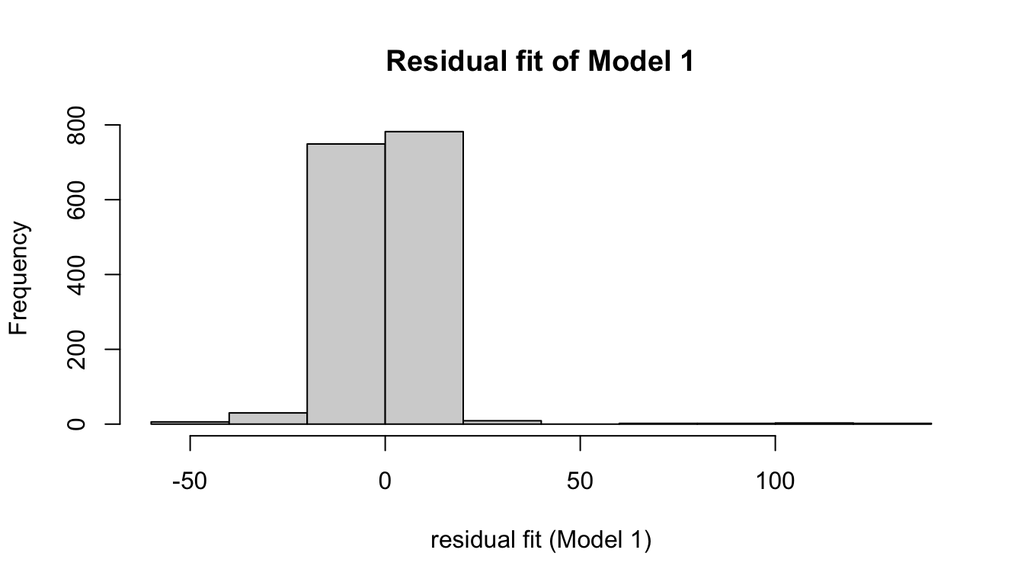

```r
hist(resid_fit1, main = "Residual fit of Model 1",
     xlab = "residual fit (Model 1)")
```

```r
shapiro.test(resid_fit1)
```

```
##
##  Shapiro-Wilk normality test
##
## data:  resid_fit1
## W = 0.73462, p-value < 2.2e-16
```

### Model 2

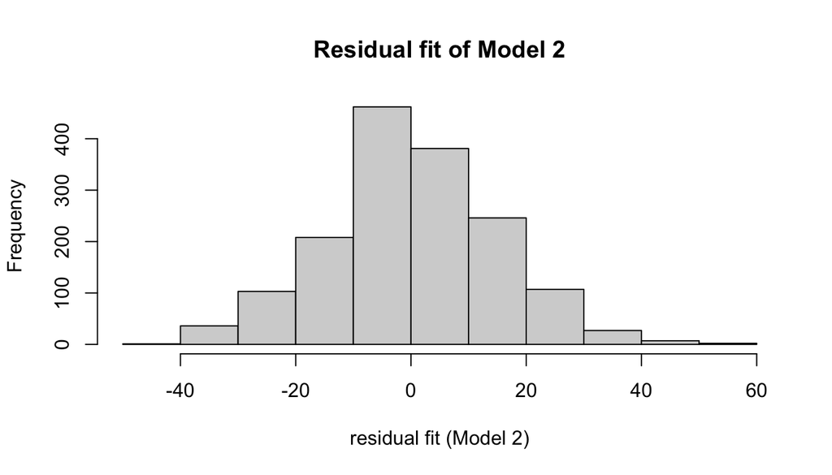

```r
hist(resid_fit2, main = "Residual fit of Model 2",
     xlab = "residual fit (Model 2)")
```

```r
shapiro.test(resid_fit2)
```

```
##
##  Shapiro-Wilk normality test
##
## data:  resid_fit2
## W = 0.99563, p-value = 0.0001541
```

### Model 3

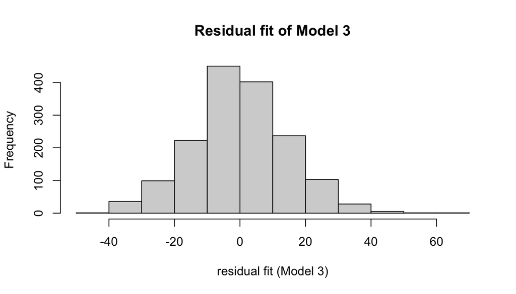

```r
hist(resid_fit3, main = "Residual fit of Model 3",
     xlab = "residual fit (Model 3)")
```

```r
shapiro.test(resid_fit3)
```

```
##
##  Shapiro-Wilk normality test
##
## data:  resid_fit3
## W = 0.99535, p-value = 8.103e-05
```

### Model 4

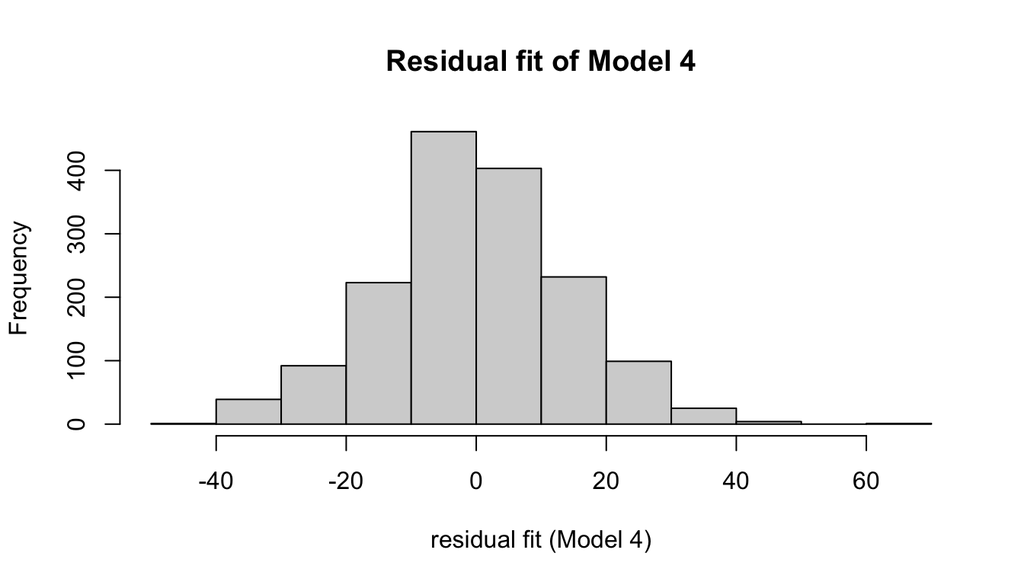

```r
hist(resid_fit4, main = "Residual fit of Model 4",
     xlab = "residual fit (Model 4)")
```

```r
shapiro.test(resid_fit4)
```

```
##
##  Shapiro-Wilk normality test
##
## data:  resid_fit4
## W = 0.99525, p-value = 6.805e-05
```

### Model 5

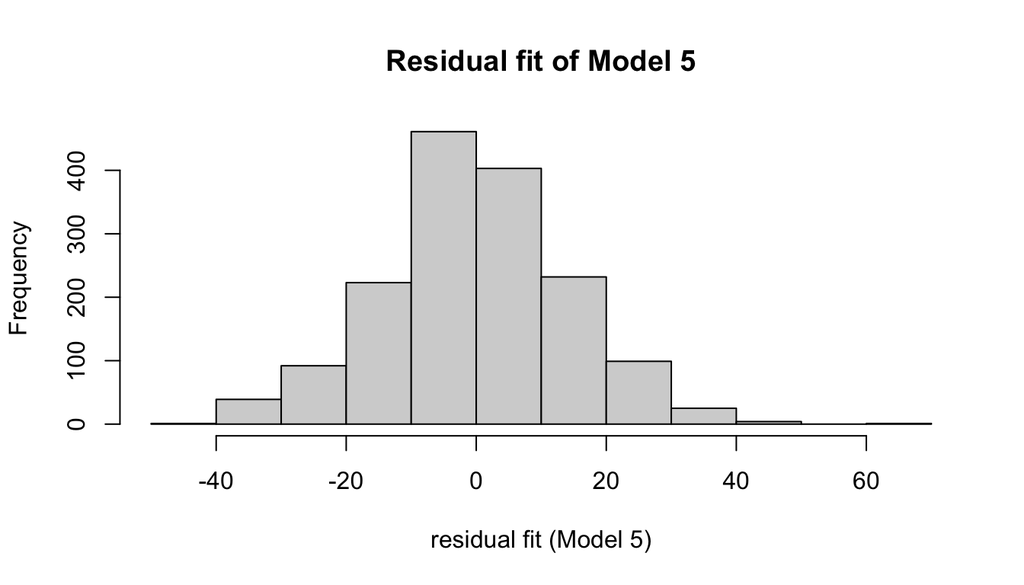

```r
hist(resid_fit5, main = "Residual fit of Model 5",
     xlab = "residual fit (Model 5)")
```

```r
shapiro.test(resid_fit5)
```

```
##
##  Shapiro-Wilk normality test
##
## data:  resid_fit5
## W = 0.99526, p-value = 6.816e-05
```

## Model Diagnostics Questions

```
1. What do you conclude about residual normality based on the numerical and graphical diagnostics?

  - For Model 1, both the graphical and numerical diagnostics for normality state that there is not a normally distributed set of data.

  - For Models 2-5, the graphical diagnostics say that they are all normally distributed, but when looking deeper into the numeric diagnostics the `shapiro.test` shows that they are not normally distributed.

2. Are violations of the normality assumption equally severe for all the models?
  -  All of models seem to equally similar, expect for model 1 residuals.
```

# Model Intepretation

## Body Length

Coefficient Table

[output not shown]

### Questions

```
1. What is the magnitude of the mass/length relationship?

  - The slope is the magnitude of the mass/length relationship which is 0.875

2. What is the expected body length of an an animal that weighs 100g?

  - 163.675

3. What is the expected body length of an animal that weighs 0g?

  - The body length of an animal that weight 0g would be the intercept or the base case. The value would be 76.125
```

## Body Mass

Coefficient Table

```r
knitr::kable(coef(summary(fit_2)))
```

|  | Estimate | Std. Error | t value | Pr(>\|t\|) |
| --- | --- | --- | --- | --- |
| (Intercept) | 42.711465 | 0.5288929 | 80.756355 | 0.0000000 |
| sexmale | 2.784133 | 0.7456117 | 3.734024 | 0.0001951 |

```r
knitr::kable(coef(summary(fit_3)))
```

|  | Estimate | Std. Error | t value | Pr(>\|t\|) |
| --- | --- | --- | --- | --- |
| (Intercept) | 46.752427 | 0.4499933 | 103.89582 | 0 |
| binomialDelomys sublineatus | -7.683058 | 0.7604562 | -10.10322 | 0 |

```r
knitr::kable(coef(summary(fit_4)))
```

|  | Estimate | Std. Error | t value | Pr(>\|t\|) |
| --- | --- | --- | --- | --- |
| (Intercept) | 45.070355 | 0.5556429 | 81.113891 | 0e+00 |
| sexmale | 3.795395 | 0.7259609 | 5.228099 | 2e-07 |
| binomialDelomys sublineatus | -8.193492 | 0.7609985 | -10.766764 | 0e+00 |

```r
knitr::kable(coef(summary(fit_5)))
```

|  | Estimate | Std. Error | t value | Pr(>\|t\|) |
| --- | --- | --- | --- | --- |
| (Intercept) | 45.0554562 | 0.6052973 | 74.4352459 | 0.0000000 |
| sexmale | 3.8280908 | 0.8966667 | 4.2692460 | 0.0000208 |
| binomialDelomys sublineatus | -8.1417394 | 1.1281046 | -7.2171847 | 0.0000000 |
| sexmale:binomialDelomys sublineatus | -0.0950187 | 1.5285856 | -0.0621612 | 0.9504424 |

### Questions

[output not shown]

## Body Mass: ANOVA

Printing out ANOVA Tables

```r
knitr::kable(anova(fit_1))
```

|  | Df | Sum Sq | Mean Sq | F value | Pr(>F) |
| --- | --- | --- | --- | --- | --- |
| body_mass | 1 | 269388.9 | 269388.9086 | 1976.957 | 0 |
| Residuals | 1583 | 215706.6 | 136.2645 | NA | NA |

```r
knitr::kable(anova(fit_2))
```

|  | Df | Sum Sq | Mean Sq | F value | Pr(>F) |
| --- | --- | --- | --- | --- | --- |
| sex | 1 | 3061.678 | 3061.6779 | 13.94294 | 0.0001951 |
| Residuals | 1578 | 346507.131 | 219.5863 | NA | NA |

```r
knitr::kable(anova(fit_3))
```

|  | Df | Sum Sq | Mean Sq | F value | Pr(>F) |
| --- | --- | --- | --- | --- | --- |
| binomial | 1 | 21289.68 | 21289.6805 | 102.0751 | 0 |
| Residuals | 1583 | 330164.45 | 208.5688 | NA | NA |

```r
knitr::kable(anova(fit_4))
```

|  | Df | Sum Sq | Mean Sq | F value | Pr(>F) |
| --- | --- | --- | --- | --- | --- |
| sex | 1 | 3061.678 | 3061.6779 | 14.95838 | 0.0001144 |
| binomial | 1 | 23727.134 | 23727.1342 | 115.92320 | 0.0000000 |
| Residuals | 1577 | 322779.997 | 204.6798 | NA | NA |

```r
knitr::kable(anova(fit_5))
```

|  | Df | Sum Sq | Mean Sq | F value | Pr(>F) |
| --- | --- | --- | --- | --- | --- |
| sex | 1 | 3.061678e+03 | 3.061678e+03 | 14.948932 | 0.0001150 |
| binomial | 1 | 2.372713e+04 | 2.372713e+04 | 115.849977 | 0.0000000 |
| sex:binomial | 1 | 7.913846e-01 | 7.913846e-01 | 0.003864 | 0.9504424 |
| Residuals | 1576 | 3.227792e+05 | 2.048091e+02 | NA | NA |

### Questions

```
1. Are sex and species significant predictors for body mass?
  - yes because the p value is less than 0.05.

2. Is there a significant interaction?
  - There is not a significant interaction

3. Does the significance (as measured by p-value) of either of the main effects (sex and species) differ much between the single-predictor models, the additive model, and the interactive model?
  - No they do not
```

# Model Comparison: Body Mass

```r
AIC(fit_1)
```

```
## [1] 12291.67
```

```r
AIC(fit_2)
```

```
## [1] 13006.8
```

```r
AIC(fit_3)
```

```
## [1] 12966.36
```

```r
AIC(fit_4)
```

```
## [1] 12896.73
```

```r
AIC(fit_5)
```

```
## [1] 12898.72
```

## Questions:

[output not shown]